# Hito 1: Proyecto dataset History of Hearthstone

Armin Rodríguez, Rodrigo Valenzuela, Nicolás Hidalgo, Pablo Nahuelpán

2022

# 1 Introducción

Muchas veces cuando se empieza a jugar un videojuego que requiere tener un aprendizaje extenso, los tutoriales para aprender a jugarlo no te dan buenas herramientas para que se logre tener un buen desempeño en el juego y dentro de estos se encuentra la categoría de juegos de cartas coleccionables las cuales su aprendizaje muchas veces se tiene que dar por la experiencia de estar muchas horas jugando, a continuación, se presenta uno de estos juegos.

HearthStone es un juego creado por la empresa Blizzard Entertainment, se centra dentro del universo de Warcraft juego perteneciente a la misma empresa [1]. Se juega de 2 personas 1 contra 1 y cada jugador posee un deck (o set) de cartas cada uno perteneciente a una clase, el juego además posee un sistema de clasificaciones para los usuarios que quieran jugar de manera competitiva y en este caso los jugadores pueden ir avanzando niveles dependiendo de cómo sea su desempeño en el juego, si el jugador va ganando partidas puede ir escalando de rango hasta subir al máximo nivel, y cada vez que quiera jugar el juego lo emparejará con otro jugador del mismo rango que se encuentre. Para el juego competitivo de alto nivel los jugadores expertos utilizan decks que ya son conocidos y tienen las mismas cartas, porque se le considera un deck que está dentro del meta juego o que es popular dado a que sus cartas son las mejores del juego o el deck tiene una estrategia que logra ser la mejor para jugar contra otros tipos de decks, y para encontrar estos tipos de decks primero se debe identificar que están jugando los jugadores expertos y para llegar a ese nivel se requiere de una gran cantidad de tiempo destinado en el juego que conlleva a jugar muchas partidas y ver en distintos foros del juego en internet para saber cuál es el ranking de los mejores jugadores y qué están jugando, por lo que se hace una tarea tediosa para un jugador que esta recién empezando en el juego lo que lo lleva a perder muchas partidas y en muchos casos termina por dejar el juego por frustración de que no puede ganar partidas porque los contrincantes tienen decks con mejores cartas o mejores estrategias.

En el presente informe se realizará un análisis exploratorio de datos del dataset que contiene decks utilizados por jugadores de Heartstone [1] para abordar el problema de que los jugadores novatos pierdan el interés en el juego, y mediante este análisis lograr que estos jugadores puedan comenzar a jugar con la mejor experiencia y desempeño posible, sin tener que invertir tanto tiempo buscando decks.

# 2 Exploración de datos

## 2.1 Carga de librerías y conjunto de datos.

```r
library(dplyr)
```

```r
library(ggplot2)
library(readr)
library(PerformanceAnalytics)
library(tidyr)
library(tidyverse)
decks <- read.csv("data.csv")
card_data <- read.csv("refs.csv")
names(card_data)[names(card_data) == 'id'] <- 'fid'
names(card_data)[names(card_data) == 'dbfId'] <- 'id'
```

## 2.2 Limpieza de datos

Primero se realiza una limpieza de datos para eliminar los decks que fueron creados antes del lanzamiento oficial del juego que fue el día 11 de abril de 2014.

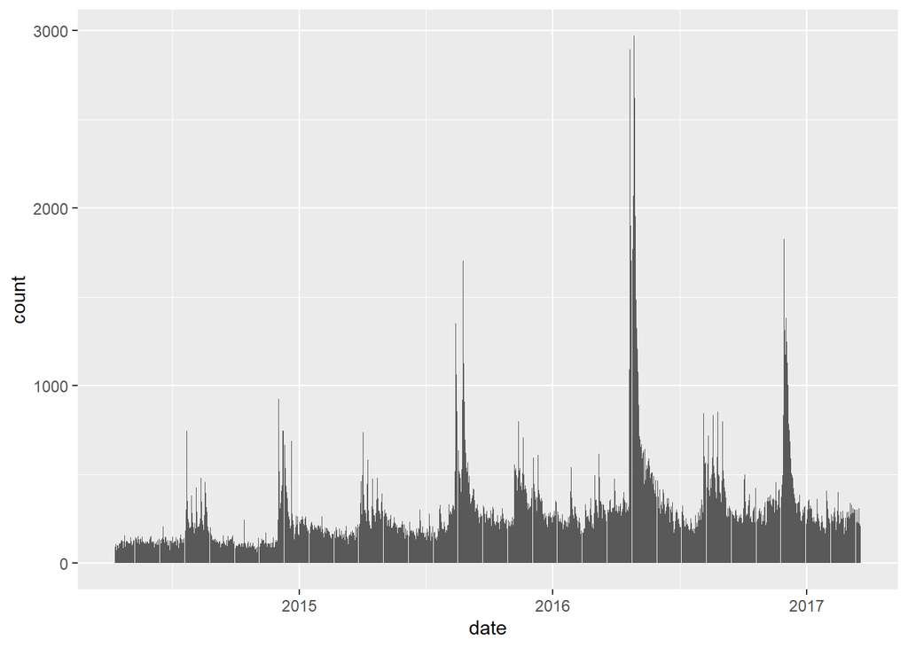

```r
decks$date <- as.Date(decks$date) # Se transforma los datos de la columna "date" en datos de tipo Date.

decks <- decks %>% filter(date >= "2014-04-11") # Se filtran los decks cuya fecha sea mayor a la fecha de lanzamiento para no contar los decks de antes de esa fecha.

st_decks <- decks %>% filter(deck_format == "S") # Se filtran los decks del formato de juego estandar.

w_decks <- decks %>% filter(deck_format == "W") # Se filtran los decks del formato de juego salvaje.

ggplot(decks) + aes(x = date) + geom_bar() # Se imprimen los decks a lo largo del tiempo.
```

Antes de empezar con el análisis del dataset en el gráfico anterior se presenta los años donde se ingresaron los decks al dataset y en qué año se ingresaron más para saber en qué año nos ubicamos.

## 2.3 Frecuencia de las razas más utilizadas

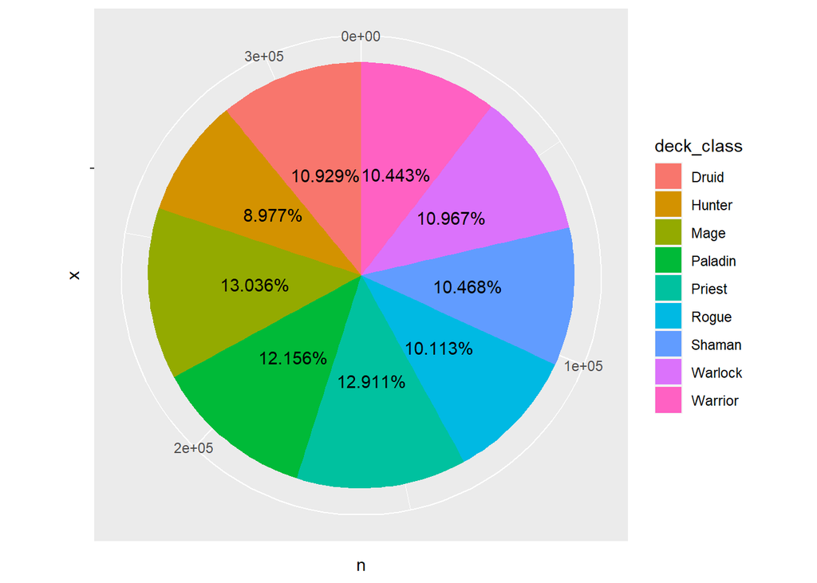

```r
classes <- decks |>
  group_by(deck_class) |>
  summarize(n = n()) |>
  mutate(pcnt = n/sum(n)) |>
  arrange(pcnt) |>
  mutate(plabel = scales::percent(pcnt))

ggplot(classes, aes(x="", y=n, fill=deck_class)) +
  geom_bar(stat="identity", width=1) +
  geom_text(aes(label = plabel),
            position = position_stack(vjust = 0.5)) +
  coord_polar("y", start=0)
```

Antes de seguir con el análisis, un buen dato que puede servir a partir del gráfico anterior es que las razas Mago, Sacerdote y Paladín son las más utilizadas por lo que se puede concluir que se pueden encontrar dentro el meta juego donde los jugadores de las altas ligas juegan decks con ese tipo de raza, dato para tener en cuenta antes de hacer un análisis porque si bien dice las razas que más se juegan, hay que averiguar si existe.

## 2.4 Cartas más usadas

```r
mage <- decks %>% filter(deck_class == "Mage")
paladin <- decks %>% filter(deck_class == "Paladin")
priest <- decks %>% filter(deck_class == "Priest")

mage <- mage[, 12:41]
paladin <- paladin[, 12:41]
priest <- priest[, 12:41]

mage_cards <- gather(mage, key = "id_cartas" ,value = "id", card_0:card_1:card_2:card_3:card_4:card_5:card_6:card_7:card_8:card_9:card_10:card_11:card_12:card_13:card_14:card_15:card_16:card_17:card_18:card_19:card_20:card_21:card_22:card_23:card_24:card_25:card_26:card_27:card_28:card_29)
```

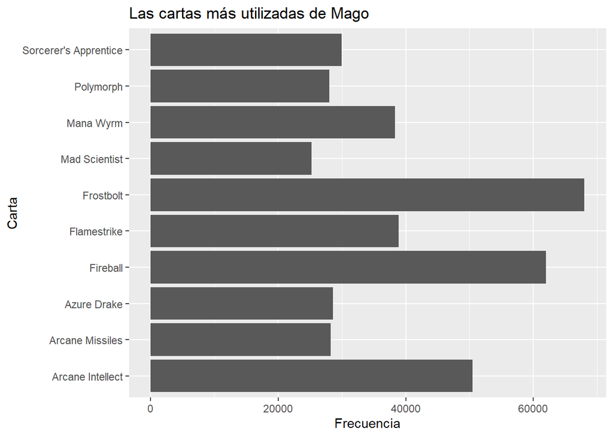

```r
id_cards_mage <- mage_cards |>
  group_by(id) |>
  summarize(freq = n())
id_cards_mage_top <- head(id_cards_mage[order(-id_cards_mage$freq),], n=10)

top_freq_mage <- id_cards_mage_top %>%
  left_join(card_data, by = "id") %>%
  mutate(cardname = name ) %>%
  select(freq,name)

ggplot(top_freq_mage) + geom_bar(aes(x = name, y = freq,), stat = "identity")  + ggtitle("Las cartas más utilizadas de Mago")+ coord_flip()  + xlab("Carta") + ylab("Frecuencia")
```

```r
paladin_cards <- gather(paladin, key = "id_cartas" ,value = "id", card_0:card_1:card_2:card_3:card_4:card_5:card_6:card_7:card_8:card_9:card_10:card_11:card_12:card_13:card_14:card_15:card_16:card_17:card_18:card_19:card_20:card_21:card_22:card_23:card_24:card_25:card_26:card_27:card_28:card_29)
```

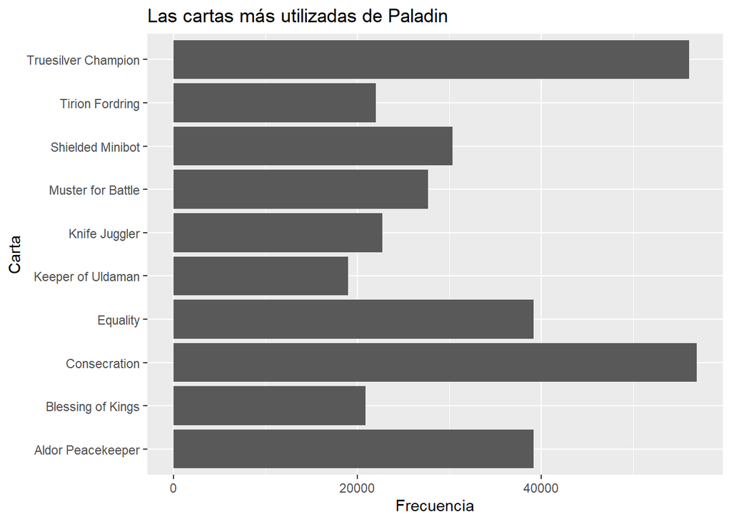

```r
id_cards_paladin <- paladin_cards |>
  group_by(id) |>
  summarize(freq = n())
id_cards_paladin_top <- head(id_cards_paladin[order(-id_cards_paladin$freq),], n=10)

top_freq_paladin <- id_cards_paladin_top %>%
  left_join(card_data, by = "id") %>%
  mutate(cardname = name ) %>%
  select(freq,name)

ggplot(top_freq_paladin) + geom_bar(aes(x = name, y = freq,), stat = "identity")  + ggtitle("Las cartas más utilizadas de Paladin")+ coord_flip()  + xlab("Carta") + ylab("Frecuencia")
```

```r
priest_cards <- gather(priest, key = "id_cartas" ,value = "id", card_0:card_1:card_2:card_3:card_4:card_5:card_6:card_7:card_8:card_9:card_10:card_11:card_12:card_13:card_14:card_15:card_16:card_17:card_18:card_19:card_20:card_21:card_22:card_23:card_24:card_25:card_26:card_27:card_28:card_29)
```

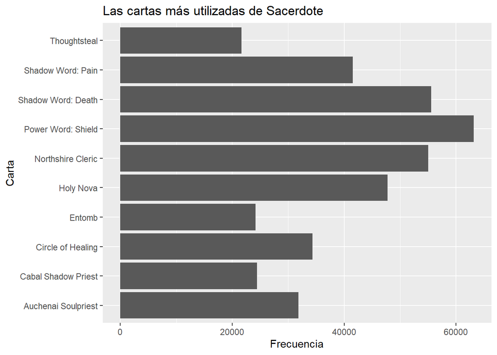

```r
id_cards_priest <- priest_cards |>
  group_by(id) |>
  summarize(freq = n())
id_cards_priest_top <- head(id_cards_priest[order(-id_cards_priest$freq),], n=10)

top_freq_priest <- id_cards_priest_top %>%
  left_join(card_data, by = "id") %>%
  mutate(cardname = name ) %>%
  select(freq,name)

ggplot(top_freq_priest) + geom_bar(aes(x = name, y = freq,), stat = "identity")  + ggtitle("Las cartas más utilizadas de Sacerdote")+ coord_flip()  + xlab("Carta") + ylab("Frecuencia")
```

Ya que conocemos cuáles son las razas más utilizadas, podríamos obtener cuales son las cartas más útiles en cada una de estas, y con esta información se pueden guiar de manera correcta los nuevos jugadores para que puedan crear las cartas necesarias para jugar con estas razas.

## 2.5 Correlación del costo de crear un deck con la cantidad de “me gusta”

```r
st_decks_numerics <- Filter(is.numeric, st_decks)

cor(st_decks_numerics$craft_cost,st_decks_numerics$rating, use = "everything", method = c("pearson", "kendall", "spearman"))
```

```
## [1] -0.007551913
```

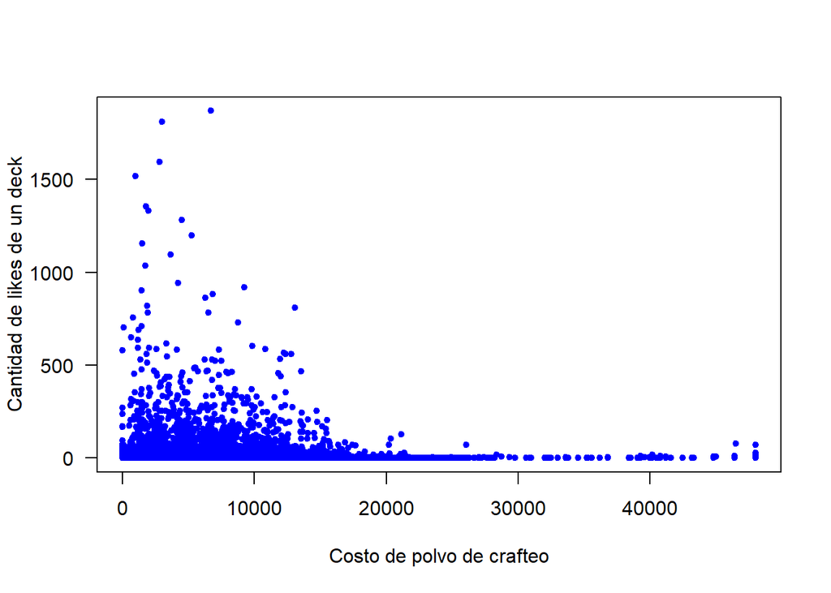

```r
with(st_decks_numerics, plot(x=craft_cost, y=rating, pch=20, col='blue',
                 xlab='Costo de polvo de crafteo', las=1,
                 ylab='Cantidad de likes de un deck'))
```

```r
w_decks_numerics <- Filter(is.numeric, w_decks)

cor(w_decks_numerics$craft_cost,w_decks_numerics$rating, use = "everything", method = c("pearson", "kendall", "spearman"))
```

```
## [1] -0.005723772
```

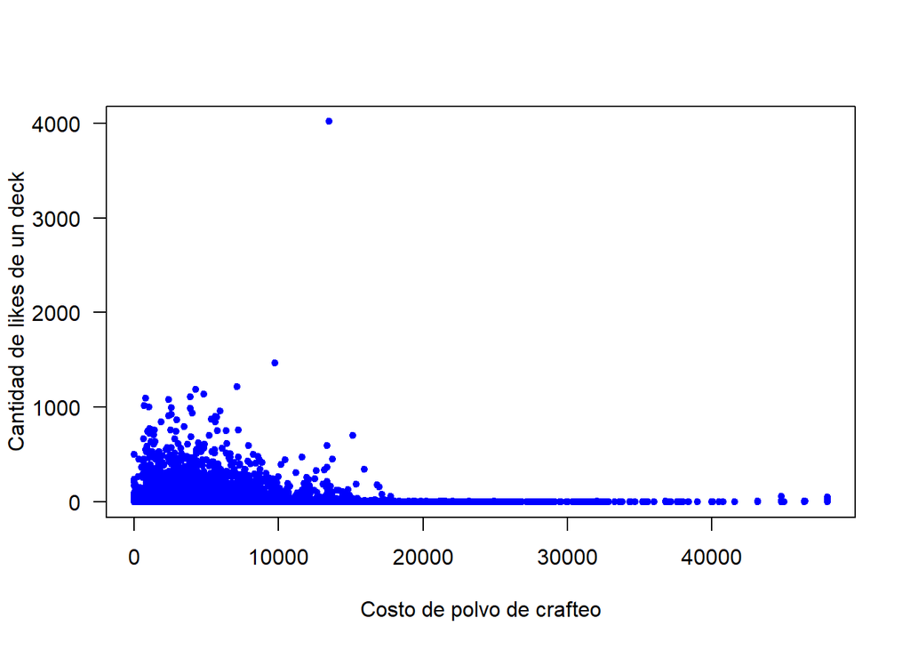

```r
with(w_decks_numerics, plot(x=craft_cost, y=rating, pch=20, col='blue',
                 xlab='Costo de polvo de crafteo', las=1,
                 ylab='Cantidad de likes de un deck'))
```

Como los decks tienen un costo en polvo para tenerlos completos, entonces se analizó cuál es la correlación entre el costo de crear un deck y la cantidad de “me gusta” del deck, entonces por lo que podemos ver existe una gran cantidad de “me gusta” por los decks entre 0 a 20.000 de polvo, por lo que podemos concluir que el juego no necesariamente se tiene que desembolsar grandes cantidades de polvo para jugar, ya que tener mucho polvo conlleva a muchas horas de juego o pagar con dinero para tenerlo de forma inmediata, y también que los decks más caros en polvo tampoco tienen tantos “me gusta” por lo que se puede deducir que las personas puede que hayan tenido un buen rendimiento con decks que tienen de costo de polvo con valor medio, por lo tanto es más importante el cómo los jugadores usan un deck con estrategia más que con tener mucho polvo para tener decks con más victorias. En el formato standart se pueden indentificar más “me gusta” que en el formato wild, pero ambos presentan una relación que la mayoría de los “me gusta” se encuentran dentro del rango de 0 a 20.000 de polvo, por lo que en ambos formatos, no es necesario pagar de más.

## 2.6 Decks competitivos de crear.

```r
decks_ranked <- filter(decks, decks$deck_type == "Ranked Deck") # Se crea un subconjunto de decks de formato competitivo.

decks_ranked <- decks_ranked[order(decks_ranked$craft_cost),]

median(decks_ranked$craft_cost) # Se obtiene la mediana de los decks de formato competitivo.
```

```
## [1] 5480
```

```r
decks_high_cost <- filter(decks_ranked, craft_cost >= 5480) # Se crea un subconjunto de decks competitivos de alto costo.

decks_low_cost_1 <- filter(decks_ranked, craft_cost < 5480) # Se crea un subconjunto de decks competitivos de bajo costo.

decks_low_cost_2 <- filter (decks_low_cost_1, craft_cost > 1200) # Se crea un subconjunto de decks con costo mayor a 1200 porque bajo de ese costo se considera deck gratuito.
```

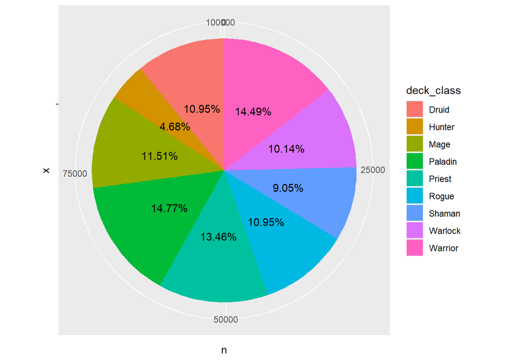

```r
#Decks de alto costo

classes <- decks_high_cost |>
  group_by(deck_class) |>
  summarize(n = n()) |>
  mutate(pcnt = n/sum(n)) |>
  arrange(pcnt) |>
  mutate(plabel = scales::percent(pcnt))

ggplot(classes, aes(x="", y=n, fill=deck_class)) +
  geom_bar(stat="identity", width=1) +
  geom_text(aes(label = plabel),
            position = position_stack(vjust = 0.5)) +
  coord_polar("y", start=0)
```

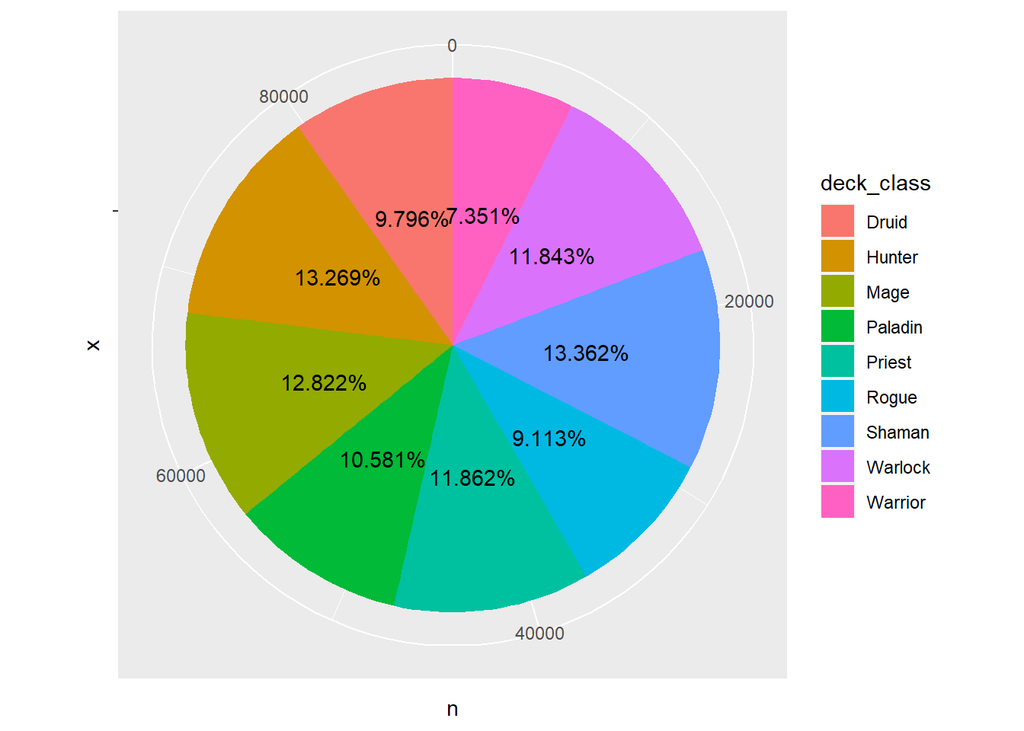

```r
#Decks de bajo costo

classes <- decks_low_cost_2 |>
  group_by(deck_class) |>
  summarize(n = n()) |>
  mutate(pcnt = n/sum(n)) |>
  arrange(pcnt) |>
  mutate(plabel = scales::percent(pcnt))

ggplot(classes, aes(x="", y=n, fill=deck_class)) +
  geom_bar(stat="identity", width=1) +
  geom_text(aes(label = plabel),
            position = position_stack(vjust = 0.5)) +
  coord_polar("y", start=0)
```

El valor de la mediana nos da 5480 por lo que los decks que tienen arriba de ese costo en polvo para crearlos se consideran decks de alto costo en el juego ya que se infiere que pueden tener una o más cartas de tipo Legendaria, las cuales son la rareza más alta del juego, por lo que para muchos, se consideran las mejores cartas e imprescindibles a la hora de crear un deck, aquellos decks que se encuentran entre 5480 y 1200 de costo, se consideran como económicos, pues estos pueden tener alguna carta legendaria, sin embargo no son imprescindibles y los decks con menor costo, se consideran como decks gratuitos porque la mayoría tienen cartas que el juego regala. Y a partir del gráfico de tortas se consideran los decks competitivos y las diferentes clases que existen por lo que vemos que con un 14.77% de Paladín, 14.49% de Guerrero y 13.46% de Sacerdote son la razas con las cartas más caras en costo de polvo por lo que se puede concluir que para entrar en el juego no es recomendable crearse un deck de esas razas y elegir entre Cazador y Chaman ya que también son competitivos pero no tienen cartas tan caras, queda también el análisis para ver cuál es el porcentaje de victorias que puede tener estas razas.

# 3 Preguntas

¿Se puede predecir si una carta nueva será popular basado en las características que posee?

¿Sera posible predecir la popularidad de un deck en base a las cartas que posee?

¿Es posible encontrar patrones dentro de cada tipo de raza para realizar recomendaciones de armado de deck a un usuario nuevo?

# 4 Referencia

[1] HeartStone. (2014, 11 marzo). [Software]. En Blizzard Entertainment (24.2). Peter McConnell. https://hearthstone.blizzard.com/es-es

# 5 Aporte de cada integrante:

- Pablo Nahuelpán estuvo a cargo de la introducción y de la correlación relacionada con la cantidad de “me gusta”, coste de los mazos y redacción de texto.
- Rodrigo Valenzuela estuvo a cargo de la limpieza de los dataset, filtrado de datos, revisión de código de sus pares y redacción de texto.
- Nicolás Hidalgo realizó el análisis correspondiente de la popularidad de los decks, en base a las razas y redacción de texto.
- Armin Rodríguez realizó corrección de algunos fragmentos de código referente a la popularidad de los decks, y análisis de referente a los decks competitivos y redacción de texto.